# Lecture 04

### 3.2.1.3 Use qualitative colour palettes for categorical data

*Qualitative*

- There is no quantitative relationship between colours.
- This is usually used for categorical data to clearly differentiate between unrelated groups.
- The lack of relationship between colours helps to highlight the distinction between categorical groups.

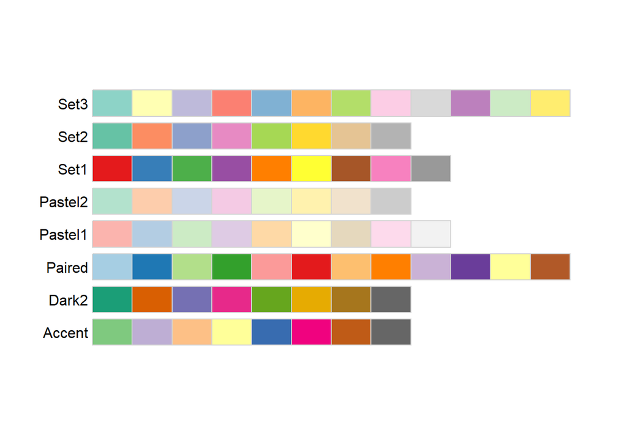

```r
display.brewer.all(type = "qual")
```

### 3.2.2 Add a colour palette to a plot like a layer

Let’s test one of the `RColorBrewer` palettes out on our data. We’ll add it as a layer to `my_plot` using `scale_fill_brewer()` to override the fill mappings defined in the `aes()` layer of the plot.

```
## Warning in RColorBrewer::brewer.pal(n, pal): n too large, allowed maximum for palette Spectral is 11
## Returning the palette you asked for with that many colors
```

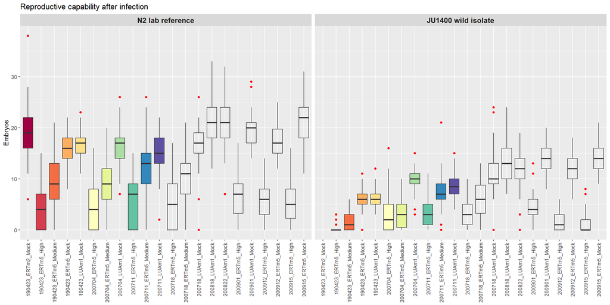

```r
my_plot + scale_fill_brewer(palette = "Spectral")
```

### 3.2.2.1 Colour palettes are not vector recycled when plotting in `ggplot`

Notice the warning we received: **“n too large…”**? Note that we have **22** different experimental categories along the x-axis but the `Spectral` palette only has **11** colours. Unlike when we saw vector recycling in previous lectures, this does not occur when supplying a colour palette with the `scale_fill_brewer()` layer to our plot. In generating our plot, we only colour the first **11** colours in each facet.

### 3.2.3 `RColorBrewer` colour palettes can be created with `brewer.pal()`

Many colour palettes now exist. I’ll showcase a couple that work nicely with `ggplot2`. These packages also have colour-blind friendly options.

`RColorBrewer` has options for these 3 types of palettes, which you can see with `display.brewer.all()`. With a smaller dataset, we could make a call in `ggplot` directly to `scale_fill_brewer()`, which just requires choosing one of `RColorBrewer`’s palettes, such as “Spectral”. However, we have 22 categories and these palettes have 8-12 colours, so we have to get creative.

Using the `brewer.pal()` function, we can pull different colours from palettes of our choosing. In our case, I have simply taken the 2 qualitative palettes that each have a length of 12, put them into one palette, and made sure the resulting vector of colour values were unique.

We can then pass this *combined* colour palette to `ggplot` via a “native” layer, `scale_fill_manual()`.

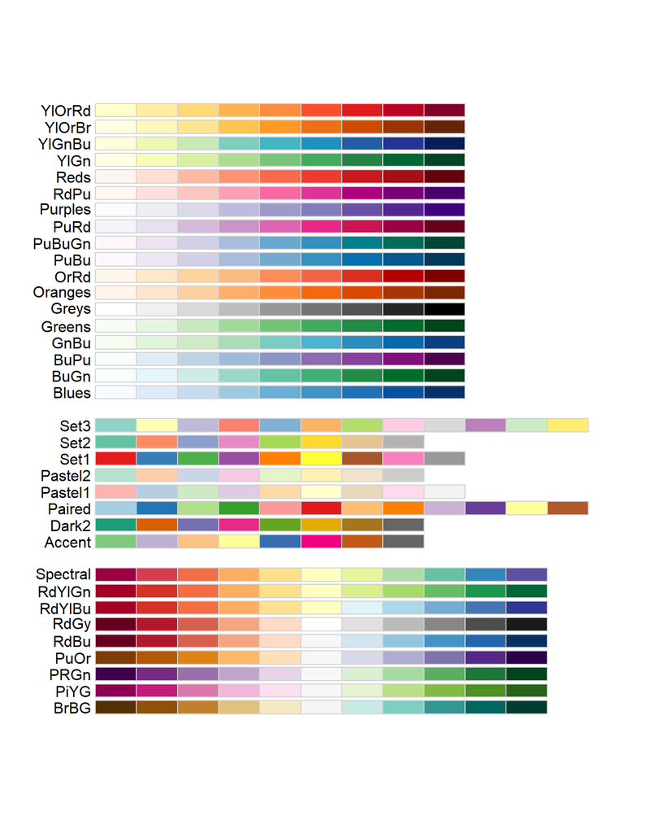

```r
display.brewer.all()
```

Looks like we can use the `Paired` and `Set3` palettes since they both have 12 colours that seem distinct enough. There may be some close colours though.

```r
# Generate 2 palettes from the longest ones
palette1 <- brewer.pal(12, "Paired")
palette2 <- brewer.pal(12, "Set3")

# combine into a single palette
custom <- unique(c(palette1, palette2))

# Do we still have enough colours?
custom
```

```
##  [1] "#A6CEE3" "#1F78B4" "#B2DF8A" "#33A02C" "#FB9A99" "#E31A1C" "#FDBF6F"
##  [8] "#FF7F00" "#CAB2D6" "#6A3D9A" "#FFFF99" "#B15928" "#8DD3C7" "#FFFFB3"
## [15] "#BEBADA" "#FB8072" "#80B1D3" "#FDB462" "#B3DE69" "#FCCDE5" "#D9D9D9"
## [22] "#BC80BD" "#CCEBC5" "#FFED6F"
```

```r
length(custom)
```

```
## [1] 24
```

Looks like we have enough colours to satisfy our needs. Notice that these are coded using a hexadecimal system? Let’s provide this vector as input.

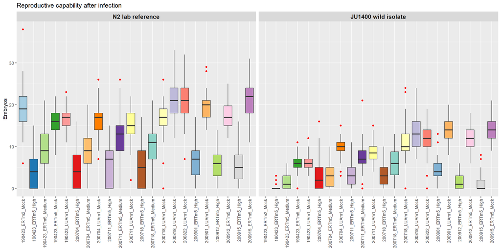

```r
# Update our plot by adding colour
my_plot + scale_fill_manual(values = custom)
```

### 3.2.4 You can always pick your own colours

You can always choose a vector of your own colors using this [R color cheatsheet](https://www.nceas.ucsb.edu/~frazier/RSpatialGuides/colorPaletteCheatsheet.pdf).

**Hexadecimal colours:** The RGB colour scheme is represented by 3 colour values (Red, Green and Blue) using a colour scale between 0-255 for each. This blending of shades produces the colours we see and can be represented by a Hexadecimal value ranging from **000000** to **FFFFFF**. Use an [RGB colourpicker](https://www.rapidtables.com/web/color/RGB_Color.html) if you are obsessed with picking your very own colour palette.

If you just want a repeating patterns of colours, you can use the `rep()` command to help you out too!

```r
# Reminder of how the rep() command works
rep(c(1,2,3,4),  # The pattern to repeat
    4)           # The number of time to repeat it
```

```
##  [1] 1 2 3 4 1 2 3 4 1 2 3 4 1 2 3 4
```

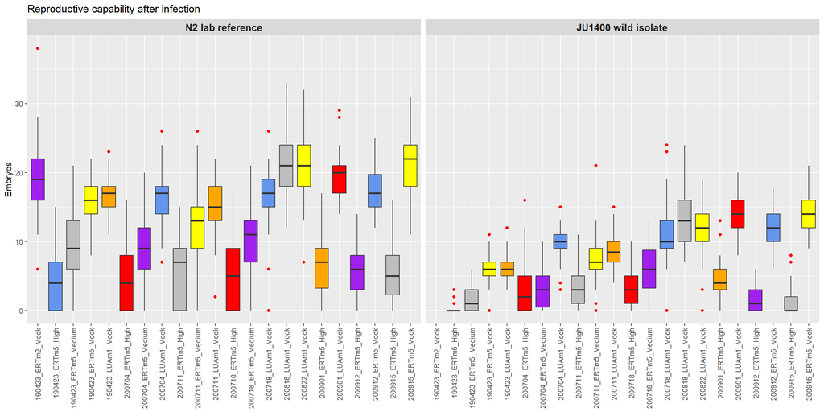

```r
# Fill the boxplot using a rep() command
my_plot + scale_fill_manual(values=rep(c("purple", "cornflowerblue", "grey", "yellow", "orange", "#FF0000"), 4))
```

### 3.2.5 Colour blind accessible palettes can be found in the `viridis` package

Sometimes you may wish to work with a colour palette that best represents a *continuous* series of diverging values. In this case you may also want to ensure your colour palette avoids issues for readers that are printing in greyscale or those that may be colour-blind. The `viridis` package contains some colour-blind accessible palettes that can also help to really differentiate between the extremes of your spectrum.

The `viridis` package also has some nice color options (https://cran.r-project.org/web/packages/viridis/vignettes/intro-to-viridis.html). While these might all be diverging palettes (qualitative is best for our `experiment` variable), we will showcase a couple here.

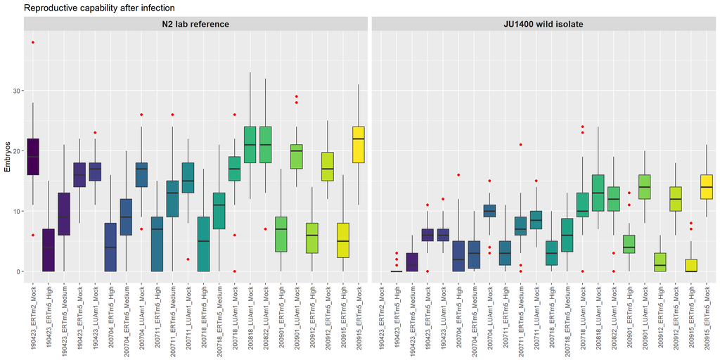

```r
# Load the viridis package
library(viridis)

# Example 1 with viridis
my_plot + scale_fill_viridis(discrete = TRUE)
```

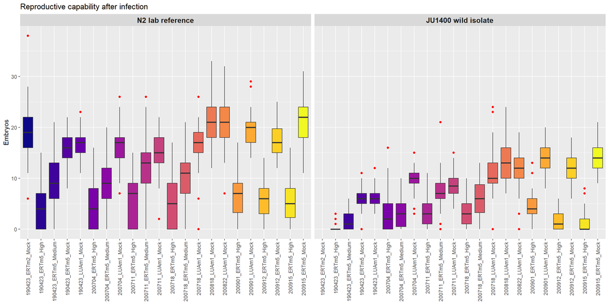

```r
# Example 2 with viridis (plasma)
my_plot + scale_fill_viridis(discrete = TRUE, option = "plasma")
```

`RSkittleBrewer` is another option for funky colour palettes. `ggsci` has a variety of color palettes inspired by different scientific journals as well as television shows (https://cran.r-project.org/web/packages/ggsci/vignettes/ggsci.html).

## 3.3.0 Theme: attributes unrelated to your data

As mentioned earlier, it is possible to customize *every single aspect* of a `ggplot`. Most of this occurs with a call to `theme()`, which you can think of as modifying everything BUT your data. For example, my axis labels can be modified, but they (hopefully) have something to do with my data. However, changing the size of the text or the font of the labels is unrelated to my data, and the same structure (text font & size) could be carried over to other plots if I saved my own theme.

Things that you can change with `theme()` include the axis, legend, panels, gridlines, or background.

Each *element* of a theme inherits from one of:

- `element_text` (text elements like font, colour, size, face (bold, italics), alignment),
- `element_line` (grid lines, axis lines),
- `element_rect` (panels and backgrounds - colour, size, fill),
- `element_blank` (assigns nothing, usually when you are trying to get rid of something),
- `element_grob` (making a grid grob).

`ggplot2` comes with some themes - I suggest starting with the one that is close to what you want, and then modifying from there.

Check out these *themes*:

- `theme_minimal()`
- `theme_classic()`
- `theme_bw()`
- `theme_void()`
- `theme_dark()`
- `theme_gray()`
- `theme_light()`

You can look at the default for each theme simply by typing it into the console.

```r
theme_bw
```

```
## function (base_size = 11, base_family = "", base_line_size = base_size/22,
##     base_rect_size = base_size/22)
## {
##     theme_grey(base_size = base_size, base_family = base_family,
##         base_line_size = base_line_size, base_rect_size = base_rect_size) %+replace%
##         theme(panel.background = element_rect(fill = "white",
##             colour = NA), panel.border = element_rect(fill = NA,
##             colour = "grey20"), panel.grid = element_line(colour = "grey92"),
##             panel.grid.minor = element_line(linewidth = rel(0.5)),
##             strip.background = element_rect(fill = "grey85",
##                 colour = "grey20"), complete = TRUE)
## }
## <bytecode: 0x0000000014c7be08>
## <environment: namespace:ggplot2>
```

And this is what `theme_bw()` practically looks like:

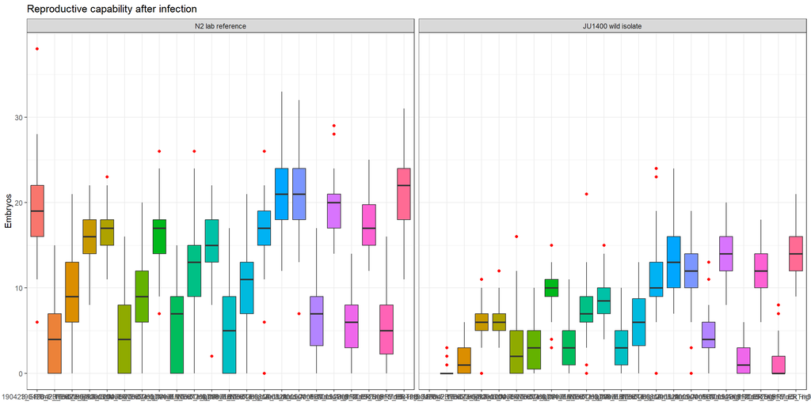

```r
# Alter the theme of my_plot
my_plot + theme_bw()
```

### 3.3.1 Remember that attribute changes are overridden by order of appearance

Notice how that last addition of the `theme_bw()` layer overrides my previous changes to the plot like x-axis text orientation? When adding `theme()` layers, the latest layer takes precedence over previous layers. Any conflicts between `theme()` layers are overridden by the newly added layers.

In our previous example, the angle of the x-axis text is returned from a vertical to a horizontal orientation since the horizontal orientation is specifically set in the `theme_bw()` layer.

Here is an example of `theme_dark()`. I am going to override the default x-axis text angle of this theme by modifying it AFTER I call `theme_dark()`.

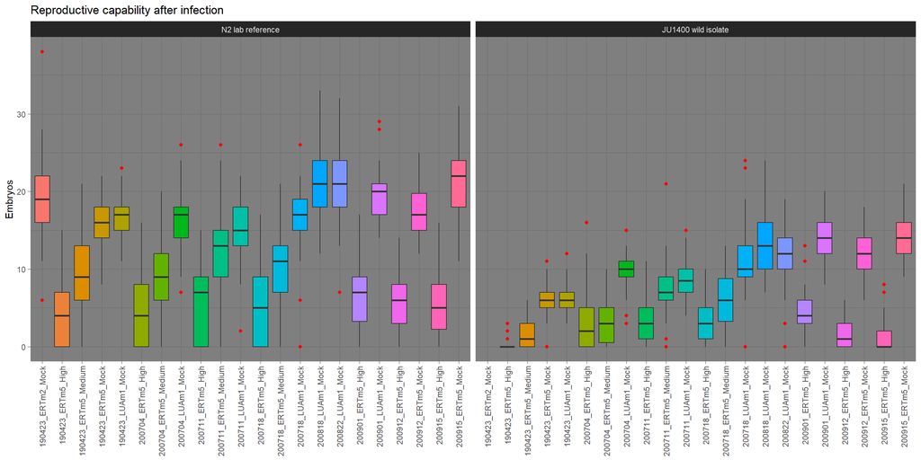

```r
# Alter my_plot and fix the x-axis
my_plot +
  theme_dark() +
  theme(axis.text.x = element_text(angle = 90, hjust = 1, vjust = 0.5))
```

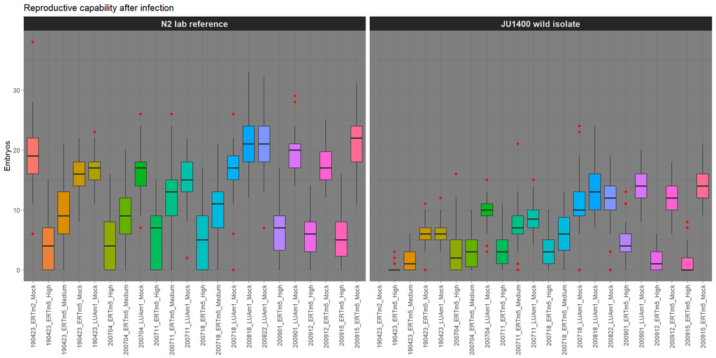

```r
# When building plots from scratch, be sure to place the theme_* above other theme changes

embryo_norm.df %>%
  # Filter for N2 observations to include infection by ERTm5 or any Mock infections
  filter(wormStrain %in% c("N2", "JU1400"),
         (sporeStrain == "ERTm5" | doseLevel == "Mock")) %>%
  filter(doseLevel %in% c("Mock", "Medium", "High")) %>%
  # We're going to make a new variable here that combines just Infection date, sporeStrain, and doseLevel
  mutate(expKey = paste(`Infection Date`, sporeStrain, doseLevel, sep="_")) %>%

  # 1. Data
  ggplot(.) +
    # 2. Aesthetics
    aes(x=expKey, y = embryos,
        fill = expKey) + # Update the fill colour using the experiment variable

    ### 3.3.1 Add the dark theme first!
    theme_dark() +
    ### 3.3.1 Then make your additional thematic adjustments
    theme(axis.text.x = element_text(angle = 90, hjust = 1, vjust = 0.5),
          strip.text.x = element_text(face = "bold", size = 12)
         ) +

    # Update our titles and remove the legend
    # Use the labs() command to set all of your labels
    labs(title = "Reproductive capability after infection",
         x = NULL,
         y = "Embryos") +
    guides(fill="none") +

    # 4. Geoms
    geom_boxplot(outlier.colour = "red") + # Specify the colour of outliers

    # 6. Facets
    facet_wrap(~wormStrain, labeller = labeller(wormStrain = wormStrain_labels)) # rename the worm strains
```

### 3.3.2 More themes are found in the `ggthemes` package

`ggthemes` is a package of themes. Some of these themes are based off of graphs seen in print or on websites (the economist, wall street journal, fivethirtyeight) or to match standard tools (excel, google docs).

**See more themes:** Information about the ggtheme options can be found at the [Github homepage](https://github.com/jrnold/ggthemes).

Here are 2 possible themes.

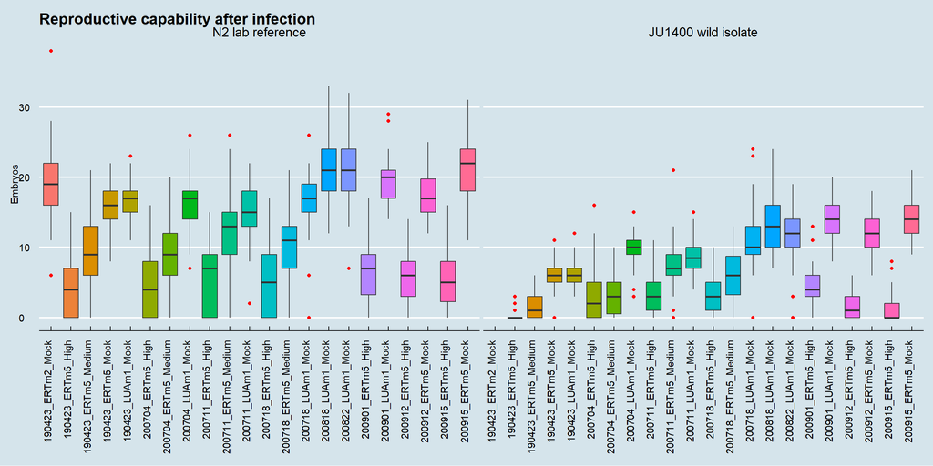

```r
# Load the ggthemes package
library(ggthemes)

# Add the economist theme to our plot
my_plot +
  theme_economist() + # Do you enjoy blue background panels?
  theme(axis.text.x = element_text(angle=90, hjust=1)) # fix the x-axis
```

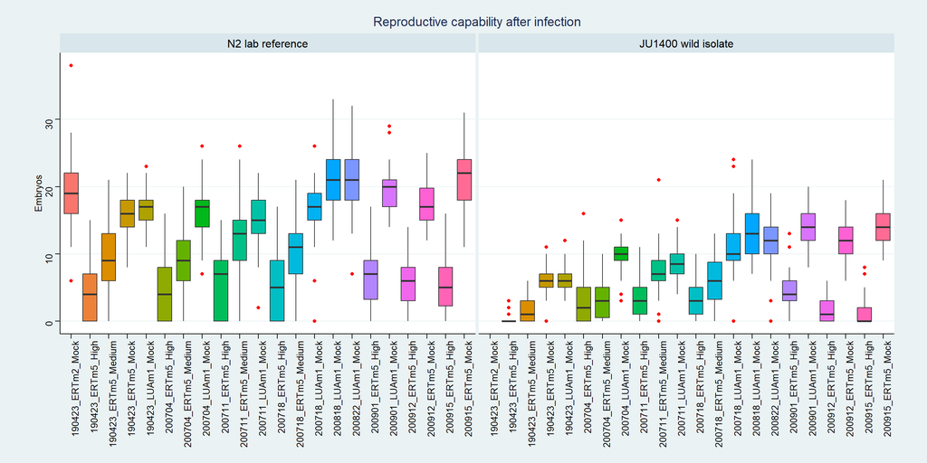

```r
# An example of replicating the style from "Stata" software
my_plot +
  theme_stata() + # Blue Plot background with white paneling
  theme(axis.text.x = element_text(angle=90, hjust=1))
```

## 3.4.0 Make a customized theme

You can also make your own custom theme as demonstrated here: http://joeystanley.com/blog/custom-themes-in-ggplot2

I am going to show you how to customize a plot, starting from `theme_minimal()` because I don’t like the grey backgrounds or harsh axis lines.

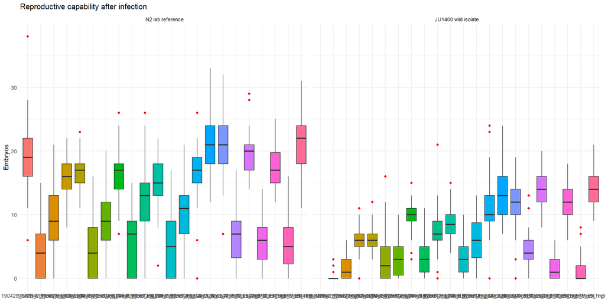

```r
# Start by using the minimal theme
my_plot +
  theme_minimal()
```

### 3.4.1 Fix your plot elements with the `theme()` layer

Depending on the layout of your plot you can institute changes to the theme as you build your plot or afterwards. Just remember, each call to `theme()` will override any previous calls that conflict, so the order of changes is important. Many arguments to `theme()` represent major element categories, but there can be arguments that specifically represent sub-categories or sub-elements.

Things I don’t like about this plot and their solutions:

| Problem | Solution | Layer / Command |
| --- | --- | --- |
| x-axis labels overlap and are small | rotate labels | **axis.text.x** |
| facet labels are smaller than axis labels | change size and face | **strip.text.x** |
| title is not centered | adjust position horizontally | **plot.title** |
| need a border to separate strains | create a border around each panel | **panel.border** |
| add y axis ticks | update y axis ticks | **axis.ticks.y** |

**Theme layers are like onions:** No, not smelly. There are just a lot of them. It isn’t necessary to remember all of this syntax! It’s certainly helpful but you can just bookmark the [ggplot2 theme reference page](http://ggplot2.tidyverse.org/reference/theme.html) instead.

As mentioned the last call to `theme()` will override previous calls that conflict. Therefore, if we want to start with `theme_minimal()` as our base, it has to be in our code BEFORE the other modifications.

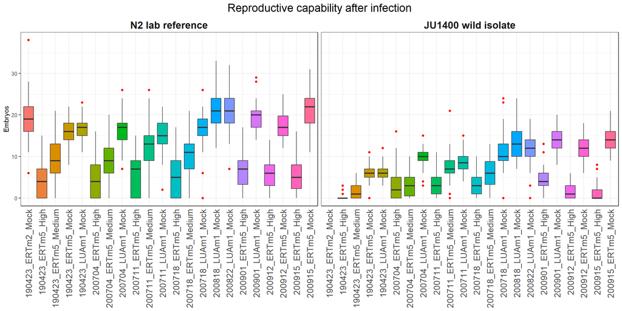

```r
# Add our own theme elements
my_plot +
  theme_minimal() + # start with theme minimal
  theme(axis.text.x = element_text(angle = 90, hjust = 1, vjust=0.5, size=14), # Adjust x-axis text and position
        panel.border = element_rect(fill=NA), # Add a panel border to each facet
        strip.text.x = element_text(face = "bold", size = 16), # alter the facet title text
        plot.title = element_text(hjust=0.5, size = 18), # Centre that plot title
        axis.ticks.y = element_line()) # Add some little tick marks on the y-axis
```

```r
# Note that you could break this into multiple theme() calls as well!
```

There are a lot of way to customize your plots! Keep exploring and playing with parameters!

### 3.4.2 Save your personalized themes to a variable

You may be wondering, “Can I save this *awesome* theme to apply to all my *amazing* plots?” Yes, there are a number of ways to import your themes to other scripts if you learn to save your data objects to file in **Lecture 07**! For now, you can assign your themes to a variable and apply them to plots like any other layer.

**Work smarter not harder:** A key advantage to saving your theme to a variable is that once you save it, you can apply it easily to all of your plots **but** you can also update and tweak your theme in a single place within your code or notebook, rather than across multiple code cells, etc.!

```r
# Save you theme to a variable
theme_personal <-
  theme_minimal() + # start with theme minimal
  # Our previous theme update
  theme(axis.text.x = element_text(angle = 90, hjust = 1, vjust=0.5, size=14),
        panel.border = element_rect(fill = NA),
        strip.text.x = element_text(face = "bold", size = 16),
        plot.title = element_text(hjust=0.5, size = 18),
        axis.ticks.y = element_line())
```

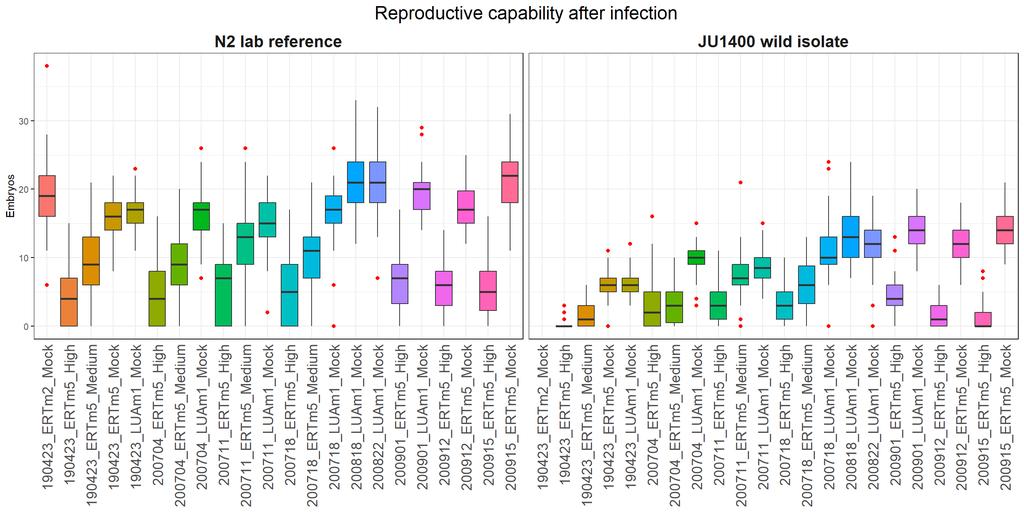

```r
# Apply your theme as a layer
my_plot + theme_personal
```

**Comprehension Question 3.0.0:** Alter the **my_plot** background to a cornflower blue and add major/minor gridlines in black. You can accomplish this by updating the **theme()** layer. Hint: you can use the **plot.background**, **panel.grid.minor**, and **panel.grid.major** arguments.

```r
# comprehension answer code 3.0.0 - updating the plot background and gridlines
# Fill the blanks
my_plot +
  theme_minimal() + # start with theme minimal
  # Our previous theme update
  theme(axis.text.x = element_text(angle = 90, hjust = 1, vjust=0.5, size=14),
        panel.border = element_rect(fill = NA),
        strip.text.x = element_text(face = "bold", size = 16),
        plot.title = element_text(hjust=0.5, size = 18),
        axis.ticks.y = element_line()) +

  # Our current theme update
  theme(..., # Set the background to a rectangle with new colour
        ..., # Add minor grid lines
          ...) # Add black major grid lines
```

# 4.0.0 Saving your figures

Up until now, we have taken for granted that our plots have been displayed using a *Graphic Device*. For our Markdown Notebooks we can see the graphs right away and update our code. You can even save them manually from the output display but sometimes you may be producing multiple visualizations based on large data sets. In this case it is preferable to save them directly to file.

## 4.1.0 Graphics Devices

- Plots must be created on a graphics device
- The default graphics device is almost always the screen device, which is most useful for exploratory analysis.
- File devices are useful for creating plots that can be included in other documents or sent to other people.
- For file devices, there are vector (pdf, svg, postscript) and bitmap (png, jpeg, tiff) formats.
- Vector formats are good for line drawings and plots with solid colors using a modest number of points.
- Bitmap formats are good for plots with a large number of points, natural scenes or web-based plots.

(https://rdpeng.github.io/Biostat776/notes/pdf/grdevices.pdf)

`ggplot2` has its own function for saving its graphics: `ggsave()`. This allows us to skip the step of explicitly calling separate graphics devices and shutting them down afterwards (if you have saved plots in base R or `lattice`, this will sound familiar to you).

You can send the plot object to the screen device to preview your image, and then save that image by specifying the file device. If you do not specify the device type, `ggsave()` will guess it from your filename extension (pdf, jpeg, tiff, bmp, svg or png). Note that this will save whatever graphic was last on your screen device.

With `ggsave()` you can minimally input the filename you would like to have, and the path to your file.

```r
# Save the last plot displayed by ggplot
ggsave("crazy_blue_graph.png", path = "data")
```

However, in some cases you want to tailor your output. You can specify the width, height and units of your image, or you can apply a scaling factor (the ‘eyeballing’ approach). You can also specify the plot object you want to save instead of whatever was on your graphics device last using the ‘plot’ parameter. Note that this time I have combined the path with the filename, and called the file device type separately.

```r
# Save our altered plot to an object
saved_plot <- my_plot + theme_personal

# Specifically make saved_plot a pdf!
ggsave("data/crazy_blue_graph2.pdf", # The path for our output
       plot = saved_plot, # The object we want to save
       device = "pdf", # explicitly name the type of file we want to make, despite the name
       scale = 2, width = 250, height = 110, units = "mm") # Set some parameters for the final size
```

No image is sent to the screen device when a file is saved in this manner.

# 5.0.0 Taking it up a notch with the `ggpub` package

There are many fantastic R packages to analyze and visualize your data. As a group, we are likely working in a variety of specialized areas. The plots we have made so far today should be useful for data exploration for many different kinds of data. In the next section we are going to preview some more complex visualization types, but since these take more time to go through and not everyone may be interested in interactive graphics, network diagrams, time-series analysis, or geospatial data, we will not be plotting all of these together. We will, however learn how to arrange multiple plots per page, and also how to make an upset plot.

## 5.1.0 Multiple plots on one page (ie. for publication images) with `ggarrange()`

There are a variety of methods to mix multiple graphs on the same page, however `ggplot2` does not work well with all of them. I am going to work with a package base called `ggpubr` which allows us to align the axes of our plots. This package relies on `gridExtra` (which allows us to arrange plots) and works well with `ggplot2`.

For a demonstration, we are going to take 3 plots that we made earlier (a beeswarm plot, a KDE plot, and a scatter plot), save them as objects, and then arrange and align them in the same figure. (http://www.sthda.com/english/rpkgs/ggpubr/)

`ggarrange()` is a function from `ggpubr` that takes your plots, their labels, and how you would like your plots arranged in rows and columns. It takes the form of:

```
ggarrange(
  ...,
  plotlist = NULL,
  ncol = NULL,
  nrow = NULL,
  labels = NULL,
  label.x = 0,
  label.y = 1,
  hjust = -0.5,
  vjust = 1.5,
  font.label = list(size = 14, color = "black", face = "bold", family = NULL),
  align = c("none", "h", "v", "hv"),
  widths = 1,
  heights = 1,
  legend = NULL,
  common.legend = FALSE,
  legend.grob = NULL
)
```

Of the parameters some relevant ones for us are:

1. `...` - the list of plots to be arranged as a grid or alternatively use…
2. `plotlist` - An optional `list` of plots to display
3. `labels` - An optional `list` of labels for each plot
4. `ncol` - number of columns in the plot grid (optional)
5. `nrow` - number of rows in the plot grid (optional)

Some examples of simple grid arrangements are :

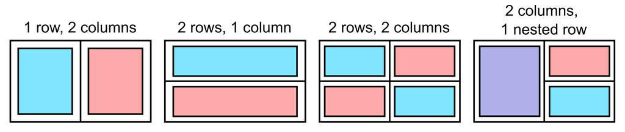

```r
# Load the ggpubr package
library(ggpubr)

# Create a KDE
densityPlot <-
  embryo_norm.df %>%
  # Filter for uninfected N2 observations
  filter(wormStrain == "N2", doseLevel == "Mock") %>%
  # 1. Data
  ggplot(.) +
    # 2. Aesthetics
    aes(x=normEmb, fill=`Infection Date`) +
    # 3. Scaling
    xlim(0.1, 2) +             ### 2.1.1 add x-axis limits
    # 4. Geoms
    geom_density(alpha=0.2) +
    geom_rug()

# Create a scatter plot
scatterPlot <-
  infection_sig.df %>%
  filter(strain %in% c("N2", "JU1400")) %>%
  # 1. Data
  ggplot(.) +
    # 2. Aesthetics
    aes(x = area, y = area.infected, colour = percent.infected) +
    # 3. Scaling
    # 4. Geoms
    geom_point(size = 2.5, alpha = 0.3) +
    # 5. statistics
    stat_smooth(method = loess, level = 0.8) + ### 1.3.1 add in some regression lines for our data
    # 6. Facets
    facet_wrap(. ~ strain, scales = "free_y") # use facet_grid to split panels by worm strain

# Set up a beeswarm for our example
beeswarmPlot <-
  boxplot +
  theme(axis.text.x = element_text(angle=0, hjust=0.5, vjust = 1)) +
  geom_quasirandom(dodge.width = 0.78, width = 0.1, alpha = 0.5)
```

Now lets arrange the scatter and KDE plots beside each other in a single row. To accomplish that we consider that `nrow=1` and `ncol=2`.

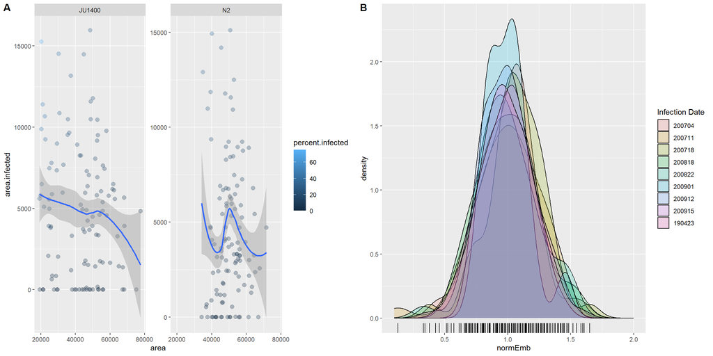

```r
# Arrange the two plots in a single page
ggarrange(scatterPlot, densityPlot, # Plots (and their order)
          labels = c("A", "B"),
          ncol = 2, nrow = 1)
```

### 5.1.1 Move legend elements around through the `guides()` and `theme()` layers

While the grid areas are of the same size, the backgrounds are not. Let’s adjust the legend of our histogram so that it is in the top right corner of the plot, and remove the white background. The movement of the legends requires a couple of layer steps to accomplish:

1. `guides()` - using this layer will allow us to denote the overall position of any attribute guide (aka legend) we’ve created. There are a few [different possible kinds of guides](https://ggplot2.tidyverse.org/reference/guides.html) like `guide_bins`, `guide_colourbar`, and `guide_legend` which will be chosen based on your type of data/legend.
2. `themes()` - we are already acquainted with this a little, but within this layer we will use the `legend.position.inside` parameter which uses a tuple (pair of numbers) where each value is {0,1}. (0,0) is the lower-left and (1,1) is the upper-right of a graph. You can also set multiple *unassigned* legends with the `legend.position` parameter if they don’t already have a designation in the `guides()` or other layers. With this paremeter, you can specify “left”, “right”, “top”, and “bottom” for positions *outside* your graph.
3. The `legend.background` parameter and others can be set to elements like a `element_rect()` but they can also be removed using the placeholder `element_blank()`. We’ll use this to make the legends backgrounds transparent when placed inside your plot panels.

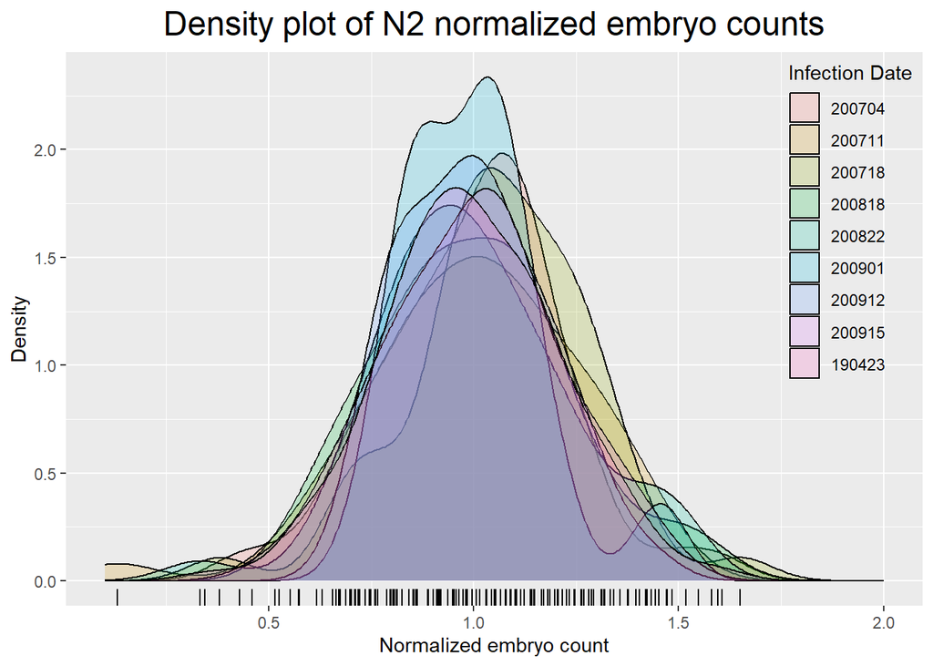

```r
##----------## Alter our KDE ##----------##
densityPlot <-
  embryo_norm.df %>%
  # Filter for uninfected N2 observations
  filter(wormStrain == "N2", doseLevel == "Mock") %>%
  # 1. Data
  ggplot(.) +
    # 2. Aesthetics
    aes(x=normEmb, fill=`Infection Date`) +
    ### 5.1.1 Set the anchor position of the legend box.
    theme(legend.justification=c(1,1),
          ### 5.1.1 Reposition the legend based on its anchor to the top right
          legend.position.inside=c(1,1),
          ### 5.1.1 Remove the background of the legend
          legend.background = element_blank(),
          plot.title = element_text(hjust=0.5, size = 18)) +

    ### 5.1.1 Send the legend to the inside of the plot
    guides(fill = guide_legend(position = "inside")) +

    # Add a title and axis labels
    labs(title = "Density plot of N2 normalized embryo counts",
         x = "Normalized embryo count",
         y = "Density") +

    # 3. Scaling
    xlim(0.1, 2) +             # add x-axis limits
    # 4. Geoms
    geom_density(alpha=0.2) +
    geom_rug()

##----------## Alter our scatter plot ##----------##
scatterPlot <-
  infection_sig.df %>%
  filter(strain %in% c("N2", "JU1400")) %>%
  # 1. Data
  ggplot(.) +
    # 2. Aesthetics
    aes(x = area, y = area.infected, colour = percent.infected) +
    ### 5.1.1 Set the anchor position of the legend box.
    theme(legend.justification=c(1,1),
          ### 5.1.1 Reposition the legend based on its anchor to the top right
          legend.position.inside=c(1,1),
          ### 5.1.1 Remove the background of the legend
          legend.background = element_blank(),
          plot.title = element_text(hjust=0.5, size = 18)) +

    ### 5.1.1 Send the legend to the inside of the plot
    guides(colour = guide_colourbar(position = "inside")) +

    # Add a title and axis labels
    labs(title = "Scatterplot of JU1400 and N2 infection signals",
         x = "Area (px^2)",
         y = "Area infected",
         colour = "% infected") +

    # 3. Scaling
    # 4. Geoms
    geom_point(size = 2.5, alpha = 0.3, ) +
    # 5. statistics
    stat_smooth(method = loess, level = 0.8) + ### 1.3.1 add in some regression lines for our data
    # 6. Facets
    facet_wrap(. ~ strain, scales = "free_y") # use facet_grid to split panels by worm strain

##----------## Alter our beeswarm plot ##----------##
beeswarmPlot <-
  boxplot +
  theme(axis.text.x = element_text(angle=0, hjust=0.5, vjust = 1)) +

  ### 5.1.1 Set the anchor position of the legend box.
  theme(legend.justification=c(1,1),
        ### 5.1.1 Reposition the legend based on its anchor to the top right
        legend.position.inside=c(1,1),
        ### 5.1.1 Remove the background of the legend
        legend.background = element_blank(),
        plot.title = element_text(hjust=0.5, size = 18)) +

    ### 5.1.1 Send the legend to the inside of the plot
    guides(fill = guide_legend(position = "inside")) +

  # Add a title and axis labels
  labs(title = "Boxplot and beeswarm of N2 infection by ERTm5",
       x = "Microsporidia dose",
       y = "Normalized embryo count",
       fill = "Dose Level") +

  geom_quasirandom(dodge.width = 0.78, width = 0.1, alpha = 0.5)

# Display our updated plots
densityPlot
```

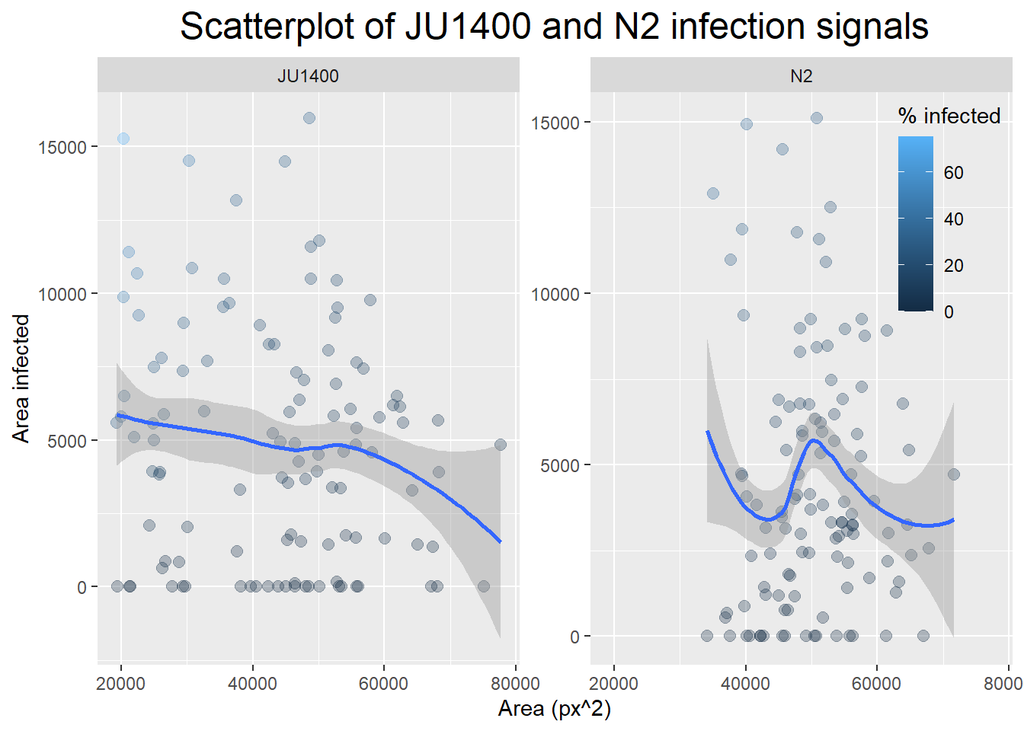

```r
scatterPlot
```

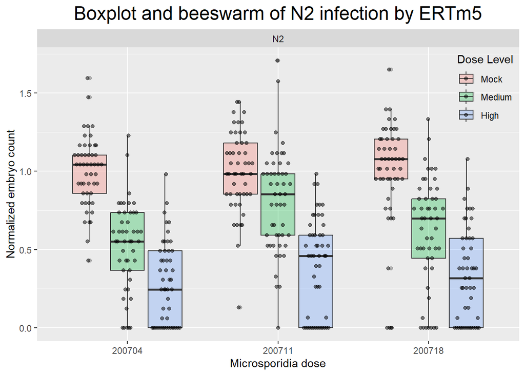

```r
beeswarmPlot
```

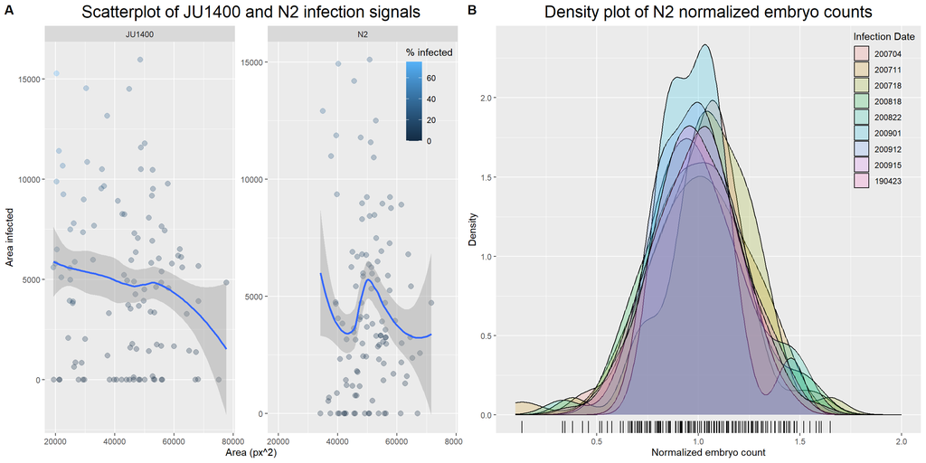

```r
# Arrange the plots again
ggarrange(scatterPlot, densityPlot,
          labels = c("A", "B"),
          ncol = 2, nrow = 1)
```

### 5.1.2 Arrange plots within plots

Next we will add in the boxplot by nesting a `ggarrange()` call within another.

Imagine a square with 4 quadrants.

1. We are going to put our beeswarm in the *left-hand side* across the top and bottom quadrants.
2. The density plot will be placed in the *top right* quadrant.
3. The scatter plot goes in the *bottom right* quadrant.

To do this, we are arranging 2 columns (one with the boxplot and one with the KDE plot + scatterplot, `ncol = 2`) and we are arranging 2 rows (one with the KDE and one with the scatterplot, `nrow = 2`).

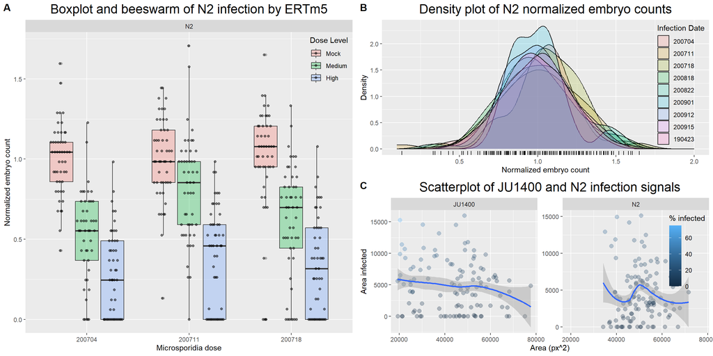

```r
# Build our new grid setup
# 1. First call initiates the 2-column grid
ggarrange(beeswarmPlot, # The left-hand column is a boxplot
          ggarrange(densityPlot, scatterPlot, # The right-hand column is a nested call with two plots
                    labels = c("B", "C"),
                    nrow = 2), # arrange the right-hand column as two rows
          ncol = 2, labels = "A") # Arrange the outer grid as two columns
```

### 5.1.3 Small changes can be made with `align` and `font()`

If y-axis lines or x-axis lines are not aligned, this can be fixed with a call to `align = "v"` or `align="h"`. Note that this will align the edges of the plot object, and not the panels that represent data alone. For the mismatch between panels B and C, you can see the titles line up but the backgrounds are off and this is due to the unit differences between each plot.

To make sure all axis titles are the same size, we can use `font()` to specify which text we want changed and the size we want to change it to. I am also going to make the legend title size the same.

Let’s look at the `font()` function, which is actually part of the `ggpubr` package. You’ll see that we can treat it much like adding a layer to our plots as we use the `+` operator. It acts like a wrapper to directly alter the `ggplot` object through underlying calls to the `theme` layer. Although limited, there are a number of elements that it can affect, including fonts for:

- The individual plot titles: “title”
- Axis and legend titles: “axis.title”, “x.title”, “y.title”, “legend.title”
- Axis labels: “xy.text” or “axis.text”

**More about the font() function:** There are a few more basic elements you can alter through this function and you can find out more at the [rdrr.io website](https://rdrr.io/cran/ggpubr/man/font.html).

Let’s try out the `font()` function now and save the result into a new variable `multiplot`. You’ll notice it’s still not quite perfect but better in many places.

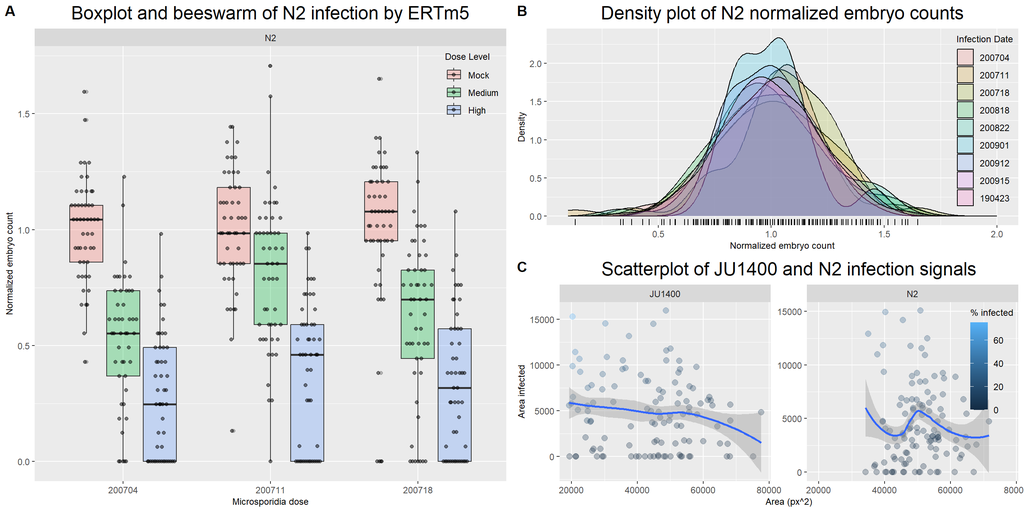

```r
# Alter the fonts of our layout
# set all axis and legend fonts to size 9
multiplot <-
ggarrange(beeswarmPlot +
            font("axis.title", size=9) +
            font("legend.title", size=9),        # Alter boxplot fonts

          ggarrange(densityPlot +
                    font("axis.title", size=9) +   # Alter KDE fonts
                    font("legend.title", size=9),

                    scatterPlot +
                    font("axis.title", size=9) +
                    font("legend.title", size=9),    # Alter scatterplot fonts

                    labels = c("B", "C"),
                    # Try to align the vertical axis of the histogram and scatterplot
                    nrow = 2, align = "v"),
           ncol = 2, labels = "A")
# View the updated plot
multiplot
```

### 5.1.4 Save your multipanel plots with `ggsave()`

The `ggarrange` objects, while structurally different from `ggplot` objects, inherit much of their information and behaviours from the `ggplot` class. Therefore, you can use other `ggplot` functions like `ggsave()` to write your plots to file. The calls follow the same format as previous examples we’ve used so let’s give it a try.

```r
# Confirm the object type of our multiplot
class(multiplot)
```

```
## [1] "gg"        "ggplot"    "ggarrange"
```

```r
# Save it to a JPEG file for using in our presentations
ggsave(plot = multiplot, file="data/multiplot.jpg", width = 200, height = 110, units = "mm")
```

**Comprehension Question 5.0.0:** Make a multi-panel combined figure using our three plots **densityPlot**, **scatterPlot**, and **beeswarmPlot**. This time, put the **densityPlot** across the top row, and beneath that, combine the **scatterPlot** and **beeswarmPlot** across the bottom row. Make sure the legend and axis titles are the same size. Change the legend text for the beeswarm/boxplot to be smaller than the legend title.

```r
# comprehension answer code 5.0.0

# Let's arrange a new set of panels
ggarrange(...)
```

## 5.3.0 Upset plots summarize your data

### 5.3.1 Venn diagrams, while popular, can be difficult to interpret

`UpSetR`: https://github.com/hms-dbmi/UpSetR

Upset plots are an alternative to Venn diagrams that show the intersection of sets, as well as the size of the sets. Additionally, Venn diagrams can be difficult to interpret for greater than 2 or 3 sets. This is a real life figure from BMC Bioinformatics. Sure it looks pretty, but what does the number 24 represent in this picture in terms of A, B, C, D, and E?

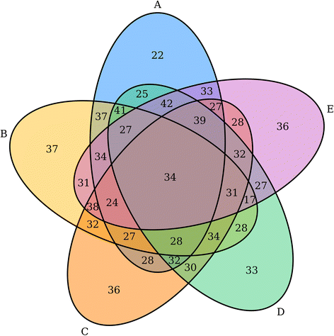

### 5.3.2 Working with `ComplexUpset` to visualize overlapping datasets

Let’s see how UpSet plots work practically. Let’s begin by importing our metadata from `data/infection_meta.csv` to help us determine the overlap in microsporidia strains tested across the various *C. elegans* worm strains used. Basically we can identify the overlap of strains between microsporidia.

```r
# Import the infection metadata
infection_meta.df <- read_csv("data/infection_meta.csv")
#Take a look at the data structure
str(infection_meta.df, give.attr = FALSE)
```

```
## spc_tbl_ [276 x 29] (S3: spec_tbl_df/tbl_df/tbl/data.frame)
##  $ experiment       : chr [1:276] "190426_VC20019_LUAm1_0M_72hpi" "190426_VC20019_LUAm1_10M_72hpi" "190426_VC20019_LUAm1_20M_72hpi" "190426_N2_LUAm1_0M_72hpi" ...
##  $ experimenter     : chr [1:276] "CM" "CM" "CM" "CM" ...
##  $ description      : chr [1:276] "Wild isolate phenoMIP retest" "Wild isolate phenoMIP retest" "Wild isolate phenoMIP retest" "Wild isolate phenoMIP retest" ...
##  $ Infection Date   : num [1:276] 190423 190423 190423 190423 190423 ...
##  $ Plate Number     : num [1:276] 1 2 3 4 5 6 7 8 9 10 ...
##  $ Worm_strain      : chr [1:276] "VC20019" "VC20019" "VC20019" "N2" ...
##  $ Total Worms      : num [1:276] 1000 1000 1000 1000 1000 1000 1000 1000 1000 1000 ...
##  $ Spore Strain     : chr [1:276] "LUAm1" "LUAm1" "LUAm1" "LUAm1" ...
##  $ Spore Lot        : chr [1:276] "2A" "2A" "2A" "2A" ...
##  $ Lot concentration: num [1:276] 176000 176000 176000 176000 176000 176000 176000 176000 176000 176000 ...
##  $ Total Spores (M) : num [1:276] 0 10 20 0 10 20 0 10 20 0 ...
##  $ Total ul spore   : num [1:276] 0 56.8 113.6 0 56.8 ...
##  $ Infection Round  : num [1:276] 1 1 1 1 1 1 1 1 1 1 ...
##  $ 40X OP50 (mL)    : num [1:276] 0.15 0.15 0.15 0.15 0.15 0.15 0.15 0.15 0.15 0.15 ...
##  $ Plate Size       : num [1:276] 6 6 6 6 6 6 6 6 6 6 ...
##  $ Spores(M)/cm2    : num [1:276] 0 0.354 0.708 0 0.354 ...
##  $ Time plated      : num [1:276] 1300 1300 1300 1300 1300 1300 1300 1300 1300 1300 ...
##  $ Time Incubated   : num [1:276] 1600 1600 1600 1600 1600 1600 1600 1600 1600 1600 ...
##  $ Temp             : num [1:276] 21 21 21 21 21 21 21 21 21 21 ...
##  $ timepoint        : chr [1:276] "72" "72" "72" "72" ...
##  $ infection.type   : chr [1:276] "continuous" "continuous" "continuous" "continuous" ...
##  $ Fixing Date      : num [1:276] 190426 190426 190426 190426 190426 ...
##  $ Location         : chr [1:276] "Sample exhausted" "Sample exhausted" "Sample exhausted" "Sample exhausted" ...
##  $ Staining Date    : num [1:276] 190513 190513 190513 190430 190513 ...
##  $ Stain type       : chr [1:276] "Sp.9 FISH + DY96" "Sp.9 FISH + DY96" "Sp.9 FISH + DY96" "DY96" ...
##  $ Slide date       : num [1:276] 190515 190515 190515 190501 190515 ...
##  $ Slide number     : num [1:276] 1 2 3 4 5 6 7 8 9 10 ...
##  $ Slide Box        : num [1:276] 2 2 2 2 2 2 2 2 2 2 ...
##  $ Imaging Date     : num [1:276] 190516 190516 190516 190502 190516 ...
```

### 5.3.3 Format your data for ComplexUpset

The data we have represents 276 experimental conditions each noting which worm strains were tested against various microsporidia strains. We’ll want to simplify all this information using our standard `group_by()` and `summarise()` paradigm. For simplicity, we’ll capture the number of instances of each worm strain/spore strain combination in our experiments.

The format we want to generate is to have our categories as columns (ie spores), and our observations as rows (ie worm strains). To accomplish that, we’ll have to further `pivot_wider()` our summarised data. Let’s save the result to a new variable `infection_combinations.df`.

```r
# save our results to this variable
infection_combinations.df <-
  # Pass along the metadata
  infection_meta.df %>%
  # Group by worm strain and spore strain
  group_by(Worm_strain, `Spore Strain`) %>%
  # Count occurences within each group
  summarise(nTotal = n()) %>%
  # Ungroup the data
  ungroup() %>%
  # Pivot the summary table to move the spore strain names as their own columns
  pivot_wider(names_from = `Spore Strain`, values_from = nTotal, values_fill = 0)
# Take a peek at the result
head(infection_combinations.df)
```

```
## # A tibble: 6 x 11
##   Worm_strain LUAm1 ERTm5 AWRm78 `ERTm5-96H` `LUAm1-HK` `LUAm1-pel` `LUAm1-sup`
##   <chr>       <int> <int>  <int>       <int>      <int>       <int>       <int>
## 1 AB1             3     0      0           0          0           0           0
## 2 AWR144          6     5      0           0          0           0           0
## 3 AWR145          6     5      0           0          0           0           0
## 4 CB4856          0     3      0           0          0           0           0
## 5 ED3042          3     0      0           0          0           0           0
## 6 ED3052A         7     0      0           0          0           0           0
## # i 3 more variables: LUAm3 <int>, MAM1 <int>, ERTm2 <int>
```

```r
str(infection_combinations.df, give.attr = FALSE)
```

```
## tibble [21 x 11] (S3: tbl_df/tbl/data.frame)
##  $ Worm_strain: chr [1:21] "AB1" "AWR144" "AWR145" "CB4856" ...
##  $ LUAm1      : int [1:21] 3 6 6 0 3 7 7 30 2 0 ...
##  $ ERTm5      : int [1:21] 0 5 5 3 0 0 0 27 1 3 ...
##  $ AWRm78     : int [1:21] 0 0 0 0 0 0 0 3 0 0 ...
##  $ ERTm5-96H  : int [1:21] 0 0 0 0 0 0 0 6 0 0 ...
##  $ LUAm1-HK   : int [1:21] 0 0 0 0 0 0 0 1 0 0 ...
##  $ LUAm1-pel  : int [1:21] 0 0 0 0 0 0 0 1 0 0 ...
##  $ LUAm1-sup  : int [1:21] 0 0 0 0 0 0 0 1 0 0 ...
##  $ LUAm3      : int [1:21] 0 0 0 0 0 0 0 3 0 0 ...
##  $ MAM1       : int [1:21] 0 0 0 0 0 0 0 6 1 0 ...
##  $ ERTm2      : int [1:21] 0 0 0 0 0 0 0 0 0 0 ...
```

### 5.3.3.1 `mutate()` values in multiple columns using the `across()` helper

Our resulting tibble now has 21 rows (worm strains) and 11 columns (spore strains). Before we continue we want to convert all of the values representing spore strains to either 0 or 1. Any entries with a value of 1 or more (present) can be converted just to 1, and 0 (not present) will remain 0. There are a few ways we could do this but we’ll do a simple mutate and use the `~` syntax again to define a quick function.

```r
# Replace our combo information with the new values of either 0 or 1
infection_combinations.df <-
  # Pass the combinations tibble
  infection_combinations.df %>%
  # Mutate columns 2-11
  mutate(across(.cols = c(2:11),
                .fns = ~ as.numeric(.x > 0)))
                # Define our function by casting a conditional result to numeric
                # You could also cast ~as.numeric(as.logical(.x)) instead

head(infection_combinations.df)
```

```
## # A tibble: 6 x 11
##   Worm_strain LUAm1 ERTm5 AWRm78 `ERTm5-96H` `LUAm1-HK` `LUAm1-pel` `LUAm1-sup`
##   <chr>       <dbl> <dbl>  <dbl>       <dbl>      <dbl>       <dbl>       <dbl>
## 1 AB1             1     0      0           0          0           0           0
## 2 AWR144          1     1      0           0          0           0           0
## 3 AWR145          1     1      0           0          0           0           0
## 4 CB4856          0     1      0           0          0           0           0
## 5 ED3042          1     0      0           0          0           0           0
## 6 ED3052A         1     0      0           0          0           0           0
## # i 3 more variables: LUAm3 <dbl>, MAM1 <dbl>, ERTm2 <dbl>
```

### 5.3.4 Use the `upset()` function to generate an UpSet plot

Now that we’ve properly formatted our table `infection_combinations.df`, it has 21 rows (worm strains) by 11 columns (10 spore strains we are investigating)

To use the `upset()` plotting function, we enter our data set, the number of sets we are inputting, if we want to order the results (in this case by frequency), and how many intersections we want to show. Here, I will show 15 intersections - we know the remaining intersections would be zero since this is ordered by frequency.

**Watch out!** Remember we said that the tibble and data frame were interchangeable for *most* cases? When we venture outside the *tidyverse* we may not be afforded the same courtesy. In the case of the **ComplexUpset** package, it prefers to work with **data.frames** instead of **tibble** objects.

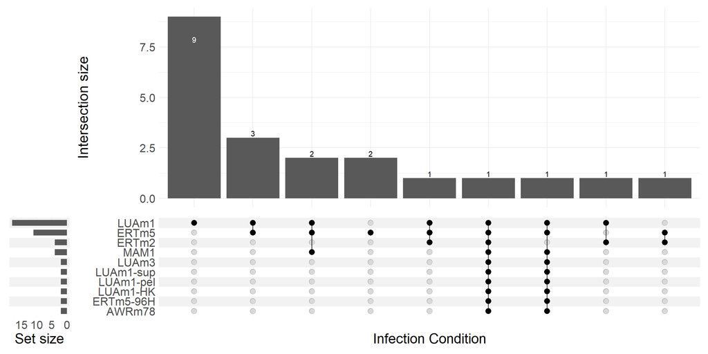

```r
# Load the UpSetR package
library(ComplexUpset)

      # Our dataset
upset(as.data.frame(infection_combinations.df),
      # Name the columns we want to analyse
      intersect = colnames(infection_combinations.df)[2:11],
      # Set the label below the intersection matrix
      name = "Infection Condition",
      # Make the set size width a little smaller
      width_ratio = 0.1,
      # Require a minimum of 1 instance to show an intersection
      min_size = 1,
      # Set the max number of intersections we want to plot
      n_intersections = 15,
      # Set the plot text size to be 20
      themes = upset_default_themes(text = element_text(size = 20))
     )
```

```r
# This UpSet plot shows testing occurrence between worm strains and spore strains
```

### 5.3.5 Understanding our Upset plot

Our plot can be broken into 3 sections.

1. The left-hand barplot denotes the number of observations in each set/category.
2. The bottom plot graphically represents the different combinations of each category up to `nintersects`.
3. The upper barplot displays the number of occurrences for the combination displayed in the bottom plot.

## 5.4.0 But wait, there’s more!

While we have just scratched the surface of `ggplot`, as mentioned earlier in lecture there are many additional visualization packages that can work with more specific types of data. In some cases, these packages add functionality to the `ggplot` package itself!

### 5.4.1 Interactive graphics

`Plotly`: https://plot.ly/r/

`ggvis`: http://ggvis.rstudio.com/interactivity.html

Heatmaps: https://github.com/talgalili/heatmaply

Interactive time-series data: https://rstudio.github.io/dygraphs/

### 5.4.2 Network diagrams

`visNetwork` (based on igraph): https://datastorm-open.github.io/visNetwork/edges.html

### 5.4.3 Circos Plots

Migest: https://gjabel.wordpress.com/category/r/migest/

### 5.4.4 Geospatial Data

Static Maps: - https://bhaskarvk.github.io/user2017.geodataviz/notebooks/02-Static-Maps.nb.html

Interactive Maps: - https://bhaskarvk.github.io/user2017.geodataviz/notebooks/03-Interactive-Maps.nb.html

### 5.4.5 Phylogenetics Data

`ggtree`: - http://www.bioconductor.org/packages/3.7/bioc/vignettes/ggtree/inst/doc/treeAnnotation.html#annotate-clades

`treeman`: - https://bmcresnotes.biomedcentral.com/articles/10.1186/s13104-016-2340-8

`metacoder`: - https://github.com/grunwaldlab/metacoder

`phyloseq`: - https://joey711.github.io/phyloseq/index.html

### 5.4.6 Genomics Data

`ggbio`: - http://www.bioconductor.org/packages/2.11/bioc/vignettes/ggbio/inst/doc/ggbio.pdf

`GenVisR`: - https://bioconductor.org/packages/release/bioc/vignettes/GenVisR/inst/doc/Intro.html

`GenomeGraphs`: - https://bmcbioinformatics.biomedcentral.com/articles/10.1186/1471-2105-10-2

# 6.0.0 Class summary

That’s the end for our fourth class on R! We took a break from data wrangling this week to focus on the basics of data visualization including:

1. Understanding the grammar of graphics philosophy.
2. Producing basic plots: scatterplot, barplots, and boxplots.
3. Customizing plot elements and themes
4. Saving your plots to file
5. Arranging multiple plots into a single canvas.
6. Packages outside of `ggplot`.

## 6.1.0 Submit your completed skeleton notebook (2% of final grade)

At the end of this lecture a Quercus assignment portal will be available to submit a **RMD** version of your completed skeletons from today (including the comprehension question answers!). These will be due one week later, before the next lecture. Each lecture skeleton is worth 2% of your final grade but a **bonus 0.5%** will also be awarded for submissions made within 24 hours from the end of lecture (ie 1600 hours the following day). To save your notebook:

1. From the RStudio Notebook in the lower right pane (**Files** tab), select the skeleton file checkbox (left-hand side of the file name)
2. Under the **More** button drop down, select the **Export** button and save to your hard drive.
3. Upload your RMD file to the Quercus skeleton portal.

[figure not shown]

## 6.2.0 Post-lecture assessment (6% of final grade)

Soon after the end of each lecture, a homework assignment will be available for you in [DataCamp](https://www.datacamp.com/). Your assignment is to complete all chapters from the **Introduction to Data Visualization with ggplot2** course which has a total of 4 chapters and 4,300 points. This is a pass-fail assignment, and in order to pass you need to achieve a least 3,225 points (75%) of the total possible points. Note that when you take hints from the DataCamp chapter, it will reduce your total earned points for that chapter.

In order to properly assess your progress on DataCamp, at the end of each chapter, please print a PDF of the summary. You can do so by following these steps:

1. Navigate to the **`Learn`** section along the top menu bar of DataCamp. This will bring you to the various courses you have been assigned under **`My Assignments`**.
2. Click on your completed assignment and expand each **chapter** of the course by clicking on the **`VIEW CHAPTER DETAILS`** link. *Do this for all sections on the page*!
3. Carefully highlight/select the page starting with the course title (ie Introduction to R) and going to the end of the last section. **Avoid** using `ctrl + A` to highlight all of the visible text.
4. Print the page from your browser menu and save as a single PDF. In the options, be sure to print “*selection*” or you may not be able to print the full page. It should print out something like what follows, except with more chapter info.

[figure not shown]

You may need to take several screenshots if you cannot print it all in a single try. Submit the file(s) or a combined PDF for the homework to the assignment section of Quercus. By submitting your scores for each section, and chapter, we can keep track of your progress, identify knowledge gaps, and produce a standardized way for you to check on your assignment “grades” throughout the course.

You will have until 1259 hours on Tuesday, September 30th to submit your assignment (right before the next lecture).

## 6.3.0 Acknowledgements

**Revision 1.0.0**: materials prepared in R Markdown by Oscar Montoya, M.Sc. *Bioinformatician, Education and Outreach, CAGEF.*

**Revision 1.1.0**: edited and prepared for **CSB1020H F LEC0142**, 09-2021 by Calvin Mok, Ph.D. *Bioinformatician, Education and Outreach, CAGEF.*

**Revision 1.1.1**: edited and prepared for **CSB1020H F LEC0142**, 09-2022 by Calvin Mok, Ph.D. *Bioinformatician, Education and Outreach, CAGEF.*

**Revision 1.1.2**: edited and prepared for **CSB1020H F LEC0142**, 09-2023 by Calvin Mok, Ph.D. *Bioinformatician, Education and Outreach, CAGEF.*

**Revision 1.2.0**: edited and prepared for **CSB1020H F LEC0142**, 09-2024 by Calvin Mok, Ph.D. *Bioinformatician, Education and Outreach, CAGEF.*

**Revision 1.2.1**: edited and prepared for **CSB1020H F LEC0142**, 09-2025 by Calvin Mok, Ph.D. *Bioinformatician, Education and Outreach, CAGEF.*

## 6.4.0 Your DataCamp academic subscription

This class is supported by DataCamp, the most intuitive learning platform for data science and analytics. Learn any time, anywhere and become an expert in R, Python, SQL, and more. DataCamp’s learn-by-doing methodology combines short expert videos and hands-on-the-keyboard exercises to help learners retain knowledge. DataCamp offers 350+ courses by expert instructors on topics such as importing data, data visualization, and machine learning. They?re constantly expanding their curriculum to keep up with the latest technology trends and to provide the best learning experience for all skill levels. Join over 6 million learners around the world and close your skills gap.

Your DataCamp academic subscription grants you free access to the DataCamp’s catalog for 6 months from the beginning of this course. You are free to look for additional tutorials and courses to help grow your skills for your data science journey. Learn more (literally!) at [DataCamp.com](https://learn.datacamp.com/).

[figure not shown]

## 6.5.0 Resources

Wickham, Hadley. (2010). A Layered Grammar of Graphics. Journal of Computational and Statistical Graphics.  
Wilkinson, L. (2005), The Grammar of Graphics (2nd ed.). Statistics and Computing, New York: Springer. [14, 18]  
Tufte, Edward R. The Visual Display of Quantitative Information.

http://www.cookbook-r.com/Graphs/  
https://github.com/jennybc/ggplot2-tutorial  
http://stcorp.nl/R_course/tutorial_ggplot2.html  
http://ggplot2.tidyverse.org/reference/theme.html  
http://joeystanley.com/blog/custom-themes-in-ggplot2  
https://github.com/jrnold/ggthemes  
https://www.nceas.ucsb.edu/~frazier/RSpatialGuides/colorPaletteCheatsheet.pdf  
https://cran.r-project.org/web/packages/ggrepel/vignettes/ggrepel.html  
http://www.cookbook-r.com/Graphs/Legends_(ggplot2)/  
https://github.com/eclarke/ggbeeswarm  
https://cran.r-project.org/web/packages/ggsci/vignettes/ggsci.html  
http://www.sthda.com/english/rpkgs/ggpubr/  
https://rpubs.com/drsong/9575  
http://elpub.bib.uni-wuppertal.de/edocs/dokumente/fbb/wirtschaftswissenschaft/sdp/sdp15/sdp15006.pdf  
http://www.sthda.com/english/articles/24-ggpubr-publication-ready-plots/81-ggplot2-easy-way-to-mix-multiple-graphs-on-the-same-page/  
https://rdpeng.github.io/Biostat776/notes/pdf/grdevices.pdf

[figure not shown]